# Statistical inference with the GSS data

## Setup

### Load packages

```r
library(ggplot2)
library(dplyr)
library(statsr)
```

### Load data

Make sure your data and R Markdown files are in the same directory. When loaded your data file will be called `gss`. Delete this note when before you submit your work.

```r
load("gss.Rdata")
```

## Part 1: Data

*Describe how the observations in the sample are collected, and the implications of this data collection method on the scope of inference (generalizability / causality). Note that you might will need to look into documentation on the GSS to answer this question. See http://gss.norc.org/ as well as the “More information on the data” section below*

**info**: Since 1972, the General Social Survey (GSS) has provided politicians, policymakers, and scholars with a clear and unbiased perspective on what Americans think and feel about such issues as national spending priorities, crime and punishment, intergroup relations, and confidence in institutions.

**Data Collection**: The vast majority of GSS data is obtained in face-to-face interviews. Computer-assisted personal interviewing (CAPI) began in the 2002 GSS. Under some conditions when it has proved difficult to arrange an in-person interview with a sampled respondent, GSS interviews may be conducted by telephone.

**Sampling**: The GSS sample is drawn using an area probability design that randomly selects respondents in households across the United States. Respondents that become part of the GSS sample are from a mix of urban, suburban, and rural geographic areas.

**Generalizability**: The inferences made from this data set are generalizable because respondents are randomly selected. The results are generalizabile to the GSS Target population, which is Adults (18+) living in ONLY households in the United States.

**Causality**: This is an observational study with no random assignment, so we cannot infer causation. * * *

## Part 2: Research question

*Research question: (3 points) Come up with a research question that you want to answer using these data. You should phrase your research question in a way that matches up with the scope of inference your dataset allows for. You are welcomed to create new variables based on existing ones. Along with your research question include a brief discussion (1-2 sentences) as to why this question is of interest to you and/or your audience.*

#### Is there sufficient evidence on the difference between respondents gender and respondents belief as to whether it should be possible for a pregnant woman to obtain a legal abortion if the woman wants it for any reason

- Abortion is an issue that primarily affects women, thus is would informative to understand whether abortion is viewed differently between men and women.

##### Data selection:

- The analysis was done using the following variables: - Abany: Abortion if woman wants for any reason (Yes or No) - Sex: Respondent’s sex (F or M)
- NA’s will be removed
- This survey started in 1972, before Roe vs. Wade (1974). Due to broad societal changes the year of the answer was captured to analyze as well, and a second variable was added to determine ‘recency’. This will be determined to be pre 2000 and post 2000.

```r
abortion <- select(gss,year,sex,abany) %>% na.omit() %>%
  mutate(recent=as.factor(ifelse(year>=2000,"R","H")))
```

## Part 3: Exploratory data analysis

```r
#look at data types
lapply(abortion, class)
```

```
## $year
## [1] "integer"
##
## $sex
## [1] "factor"
##
## $abany
## [1] "factor"
##
## $recent
## [1] "factor"
```

```r
#summary of each column of our dataframe
summary(abortion)
```

```
##       year          sex        abany       recent
##  Min.   :1977   Male  :13886   Yes:12887   H:22571
##  1st Qu.:1984   Female:17921   No :18920   R: 9236
##  Median :1991
##  Mean   :1993
##  3rd Qu.:2000
##  Max.   :2012
```

```r
#summary table
abortion_table <- table(abortion$sex,abortion$abany)
abortion_table
```

```
##
##            Yes    No
##   Male    5792  8094
##   Female  7095 10826
```

```r
#proportion table
prop.table(abortion_table)
```

```
##
##                Yes        No
##   Male   0.1820983 0.2544723
##   Female 0.2230641 0.3403653
```

```r
#proportion table H vs R
abortion_table2 <- table(abortion$sex,abortion$abany, abortion$recent)
prop.table(ftable(abortion_table2))
```

```
##                      H          R
##
## Male   Yes  0.12547552 0.05662276
##        No   0.17964599 0.07482630
## Female Yes  0.15823561 0.06482850
##        No   0.24626655 0.09409878
```

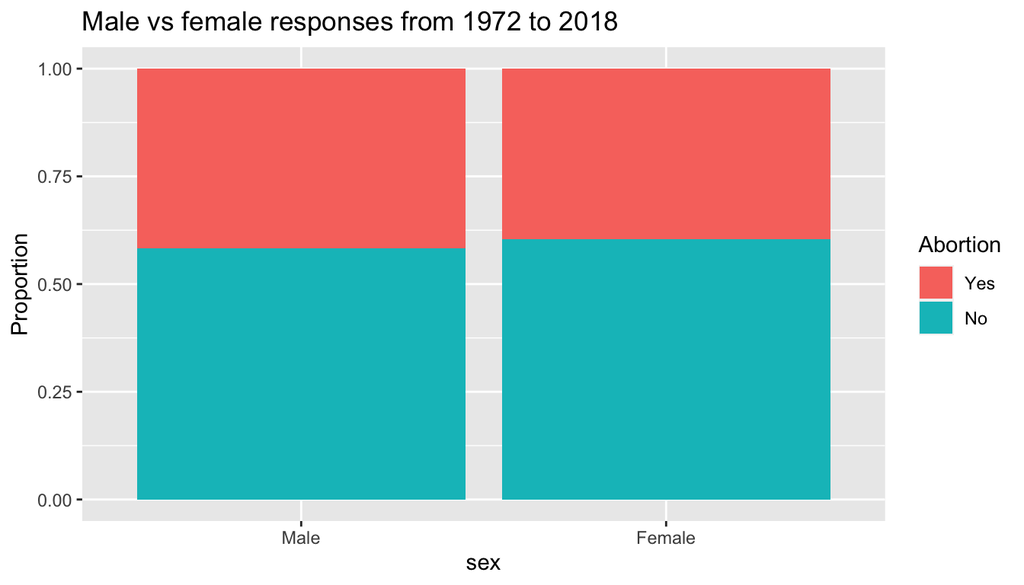

```r
ggplot(abortion, aes(x=sex,  fill = abany)) +
      geom_bar(position = "fill") +
      labs(y="Proportion",title="Male vs female responses from 1972 to 2018") +
      scale_fill_discrete(name = "Abortion")
```

- Here it seems that a slightly higher precentage of the women said no it should not be possible for a pregnant woman to obtain a legal abortion if the woman wants it for any reason

```r
since2000 <- filter(abortion,recent=="R")
summary(since2000)
```

```
##       year          sex       abany      recent
##  Min.   :2000   Male  :4181   Yes:3863   H:   0
##  1st Qu.:2002   Female:5055   No :5373   R:9236
##  Median :2006
##  Mean   :2006
##  3rd Qu.:2010
##  Max.   :2012
```

```r
#summary table
since2000_table <- table(since2000$sex,since2000$abany)
since2000_table
```

```
##
##           Yes   No
##   Male   1801 2380
##   Female 2062 2993
```

```r
#proportion table
prop.table(since2000_table)
```

```
##
##                Yes        No
##   Male   0.1949978 0.2576873
##   Female 0.2232568 0.3240580
```

[figure not shown]

```r
ggplot(since2000, aes(x=sex,  fill = abany)) +
      geom_bar(position = "fill") +
      labs(y="Proportion",title="Impact of gender on abortion views from 1972 to 2018") +
      scale_fill_discrete(name = "Abortion")
```

- we see a similar trent, that women still report a slightly higher proportion of no’s to the question of whether it should be possible for a pregnant woman to obtain a legal abortion if the woman wants it for any reason

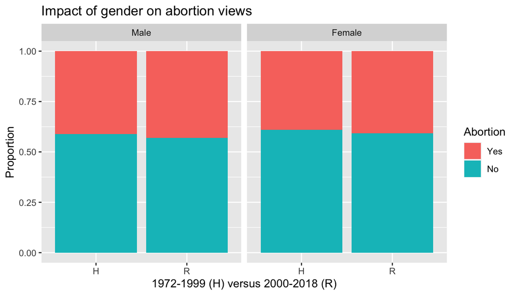

```r
ggplot(abortion) + aes(x=recent,fill=abany) + geom_bar(position = "fill") + facet_grid(.~sex) +
  labs(x="1972-1999 (H) versus 2000-2018 (R)",y="Proportion",title="Impact of gender on abortion views") +
  scale_fill_discrete(name="Abortion")
```

-overall a slightly higher percentage for both genders replies Yes in the recent era as opposed to the historical era

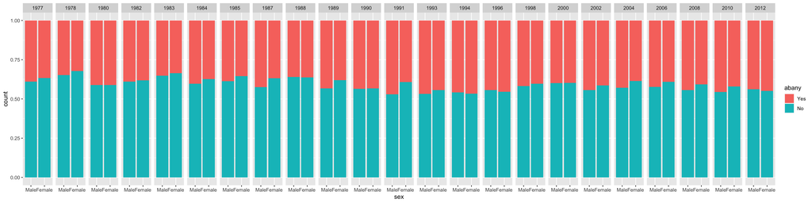

```r
ggplot(abortion) + aes(x=sex,fill=abany) + geom_bar(position = "fill") + facet_grid(.~year)
```

- looking at the proportions over the years, we can see fluctuations in the responses, but for most years, females respond no to the question more frequently than males

## Part 4: Inference

### Choose statistical method

Here we are estimating the difference between two proportions using a hypothesis test

### Define hypothesis

The null hypothesis (H0) is that there is no difference between responses among male and females The alternative hypothesis (HA) is a difference between responses among male and females

H0: $p_{male}$ - $p_{female}$ = 0

HA: $p_{male}$ - $p_{female}$ ≠ 0

- we dont have a null value of the population proportion to calculate expected successess and expected failures, so we need a pooled proportion

$$\hat{p}_{pool} = \frac{number of successes_{1} + number of successes_{2}}{n_{1} + n_{2}}$$

```r
abortion_table <- table(abortion$sex,abortion$abany)
abortion_table
```

```
##
##            Yes    No
##   Male    5792  8094
##   Female  7095 10826
```

```r
yes_male = 5792
yes_female = 7095

no_male = 8094
no_female = 10826

n_male = 5792 + 8094
n_female = 7095 + 10826
(yes_male + yes_female) / (n_male + n_female)
```

```
## [1] 0.4051624
```

**$\hat{p}_{pool} = 0.4051624$**

### Check for conditions

##### Independence

- within groups:

  ✓ random sample

  ✓ the population of the US is 328.2 million so we have much less than 10% (~ 31807)
- between groups:

  ✓ male ane female are independent of each other (non-paired)

##### Success-failure condition

✓ $n_{1}p_{1}$ ≥ 10 and $n_{1}(1-p_{1})$ ≥ 10 ✓ $n_{2}p_{2}$ ≥ 10 and $n_{2}(1-p_{2})$ ≥ 10

```r
p_pool = 0.4051624

n_male*p_pool
```

```
## [1] 5626.085
```

```r
n_male*(1-p_pool)
```

```
## [1] 8259.915
```

```r
n_female*(p_pool)
```

```
## [1] 7260.915
```

```r
n_female*(1-p_pool)
```

```
## [1] 10660.08
```

- Both independence and S-F conditions are met

### Perform the inference tests

$\hat{p}_{male} - \hat{p}_{female} \sim N(mean=0, SE = \sqrt{\frac{\hat{p}_{pool}(1- \hat{p}_{pool})}{n_1} + \frac{\hat{p}_{pool}(1- \hat{p}_{pool})}{n_2}}$

```r
numerator = p_pool*(1-p_pool)

SE = sqrt((numerator/n_male) + (numerator/n_female))
SE
```

```
## [1] 0.005550159
```

$$point.estimate = \hat{p}_{male} - \hat{p}_{female}$$

```r
pt_estimate = (yes_male/n_male) - (yes_female/n_female)
pt_estimate
```

```
## [1] 0.02120651
```

- pt_estimate = 0.02120651
- null_value = 0
- SE = 0.005550159

### P value

$$Z = (point.estimate - null.value)/SE$$

```r
pt_estimate = 0.02120651
null_value = 0
SE = 0.005550159

Z = (pt_estimate - 0)/SE
Z
```

```
## [1] 3.820883
```

```r
pnorm(q=-Z, lower.tail=FALSE)
```

```
## [1] 0.9999335
```